# Advanced Network Analysis: Bipartite (2-mode) netwpoks: Application (R)

Daniel S. Hain (dsh@business.aau.dk)

Updated October 19, 2020

```r
### Load standardpackages
library(tidyverse) # Collection of all the good stuff like dplyr, ggplot2 ect.
library(magrittr) # For extra-piping operators (eg. %<>%)

library(tidygraph)
library(ggraph)
library(igraph)
```

In this session, you will learn:

1. What are alternative ways to create network structures.
2. What are different options to visualize networks and highlight properties.
3. How to analyse multi-modal networks.

# Types of networks

We up to now already talked about different ways how networks can be constructed. Up to now, we mainly focussed on:

- Interaction between entities
- Co-occurence

However, network analysis and modelling is also fully consistent with other structures, which are often a natural outcome of supervised or unsupervised ML exercises:

- Similarities
- Hirarchies (tree-structures)

## Similarity networks

- Since similarity is a relational property between entities, similarity matrices obviously can be modeled as a network. Lets illustrate that at the classican `mtcars` example.

```r
mtcars %>% head()
```

|  | mpg | cyl | disp | hp | drat | wt | qsec | vs | am | gear | carb |
| --- | --- | --- | --- | --- | --- | --- | --- | --- | --- | --- | --- |
| Mazda RX4 | 21.0 | 6 | 160 | 110 | 3.90 | 2.620 | 16.46 | 0 | 1 | 4 | 4 |
| Mazda RX4 Wag | 21.0 | 6 | 160 | 110 | 3.90 | 2.875 | 17.02 | 0 | 1 | 4 | 4 |
| Datsun 710 | 22.8 | 4 | 108 | 93 | 3.85 | 2.320 | 18.61 | 1 | 1 | 4 | 1 |
| Hornet 4 Drive | 21.4 | 6 | 258 | 110 | 3.08 | 3.215 | 19.44 | 1 | 0 | 3 | 1 |
| Hornet Sportabout | 18.7 | 8 | 360 | 175 | 3.15 | 3.440 | 17.02 | 0 | 0 | 3 | 2 |
| Valiant | 18.1 | 6 | 225 | 105 | 2.76 | 3.460 | 20.22 | 1 | 0 | 3 | 1 |

- We could first run a PCA to reduce the dimensionality of the numerical data.

```r
cars_pca <- mtcars[,c(1:7,10,11)] %>%
  drop_na() %>%
  prcomp(center = TRUE , scale = TRUE)
```

- Next, we could create a distance matrix (using the `dist()`) function.

```r
cars_dist <- cars_pca$x %>% dist(method = "euclidean")
```

La voila. Such a distance matrix representas a relational structure and can be modelled as a network.

```r
g <- cars_dist %>%
  as.matrix() %>%
  as_tbl_graph(directed = FALSE)
```

```r
g <- g %>% simplify() %>% as_tbl_graph()
```

```r
g
```

```
# A tbl_graph: 32 nodes and 496 edges
#
# An undirected simple graph with 1 component
#
# Node Data: 32 x 1 (active)
  name
  <chr>
1 Mazda RX4
2 Mazda RX4 Wag
3 Datsun 710
4 Hornet 4 Drive
5 Hornet Sportabout
6 Valiant
# … with 26 more rows
#
# Edge Data: 496 x 3
   from    to weight
  <int> <int>  <dbl>
1     1     2  0.408
2     1     3  2.57
3     1     4  3.38
# … with 493 more rows
```

- Since the network is based on a distance matrix, we would like to reverse that to get edges representing similarity.
- Since similarity structures are usually fully connected networks, we probably also want to create some sparsity by deleting lower quantile edge weights.

```r
g <- g %E>%
  mutate(weight = max(weight) - weight) %>%
  filter(weight >= weight %>% quantile(0.75)) %N>%
  filter(!node_is_isolated()) %>%
  mutate(community = group_louvain(weights = weight) %>% factor())
```

Lets take a look!

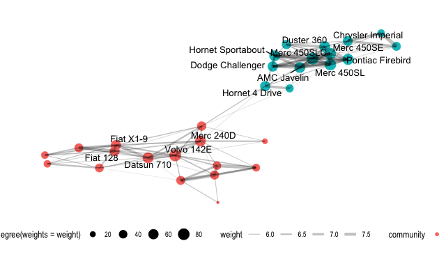

```r
set.seed(1337)
g %>% ggraph(layout = "nicely") +
  geom_node_point(aes(col = community, size = centrality_degree(weights = weight))) +
  geom_edge_link(aes(width = weight), alpha = 0.25) +
  scale_edge_width(range = c(0.1, 2)) +
  geom_node_text(aes(label = name, filter = percent_rank(centrality_degree(weights = weight)) > 0.5), repel = TRUE) +
  theme_graph() +
  theme(legend.position = 'bottom')
```

## Hierarchy (tree) networks

Hirarchical structures are obviously also relational. The difference is, that the connectivity structure tends to be constraint to other levels.

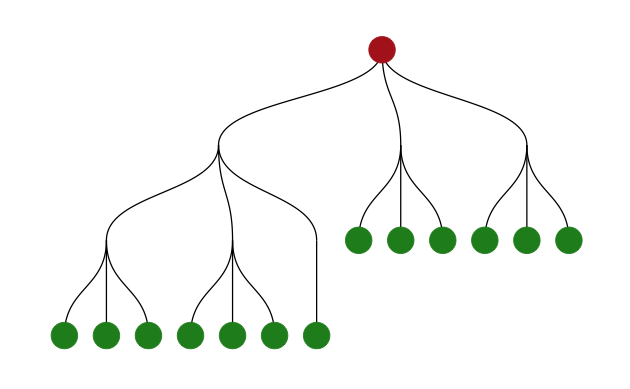

```r
create_tree(20, 3) %>%
    mutate(leaf = node_is_leaf(), root = node_is_root()) %>%
    ggraph(layout = 'tree') +
    geom_edge_diagonal() +
    geom_node_point(aes(filter = leaf), colour = 'forestgreen', size = 10) +
    geom_node_point(aes(filter = root), colour = 'firebrick', size = 10) +
    theme_graph()
```

- In addition to real life examples such as organigrams, evolutionary trees etc., many ML models result in tree-structures (eg. decision trees).
- We will at our car example execute a hierarchical clustering, which leads to a tree structure (visualized in the dendogram).

```r
cars_hc <- cars_dist %>%
  hclust(method = "ward.D2")
```

Again, this structure can be directly transfered to a graph object.

```r
g <- cars_hc %>% as_tbl_graph()
```

```r
g
```

```
# A tbl_graph: 63 nodes and 62 edges
#
# A rooted tree
#
# Node Data: 63 x 4 (active)
  height leaf  label           members
   <dbl> <lgl> <chr>             <int>
1   0    TRUE  "Porsche 914-2"       1
2   0    TRUE  "Lotus Europa"        1
3   1.62 FALSE ""                    2
4   0    TRUE  "Honda Civic"         1
5   0    TRUE  "Fiat X1-9"           1
6   0    TRUE  "Fiat 128"            1
# … with 57 more rows
#
# Edge Data: 62 x 2
   from    to
  <int> <int>
1     3     1
2     3     2
3     8     6
# … with 59 more rows
```

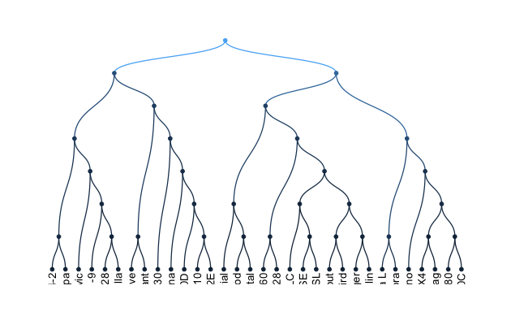

```r
g %>% ggraph(layout = 'dendrogram') +
  geom_edge_diagonal(aes(col = .N()$height[from])) +
  geom_node_point(aes(col =height)) +
  geom_node_text(aes(filter = leaf, label = label), angle=90, hjust=1, nudge_y=-0.1) +
  theme_graph() +
  theme(legend.position = 'none')
```

```r
  ylim(-0.6, NA)
```

```
<ScaleContinuousPosition>
 Range:
 Limits:    0 --    1
```

# Multi-Modal Networks

## Intuition

- Now its time to talk about an interesting type of networks, multi-modal. This means, a network has several “modes”, meaning connects entities on different conceptual levels. T
- he most common one is a **2-mode** (or **bipartite**) network.
- Examples could be an Author $\rightarrow$ Paper, Inventor $\rightarrow$ Patent, Member $\rightarrow$ Club network.
- Here, the elements in the different modes represent different things.
- We can alalyse them in seperation (and sometimes we should), but often its helpful to “project”" them onto one mode.
- Here, we create a node in one mode by joint association with another mode.

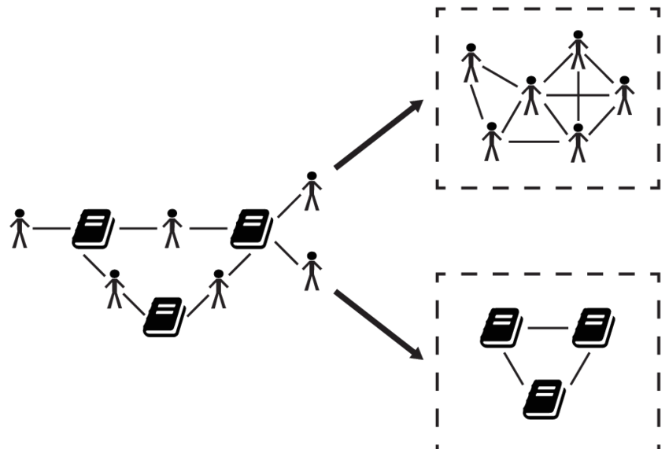

## Demonstartion

- While that sounds simple, it can be a very powerful technique, as I will demonstrate now.

```r
set.seed(1337)
g <- create_bipartite(4, 10, directed = TRUE, mode = "out") %E>%
  sample_n(15)
```

```r
people <- c('Jesper', 'Pernille', 'Morten', 'Lise', 'Christian', 'Mette', 'Casper', 'Dorte', 'Jacob', 'Helle')
places <- c('Yoga House', 'Crossfit', 'Jazz Club', 'Jomfru Anne Gade')
```

```r
g <- g %N>%
  mutate(name = c(places, people))
```

```r
g
```

```
# A tbl_graph: 14 nodes and 15 edges
#
# A directed acyclic simple graph with 3 components
#
# Node Data: 14 x 2 (active)
  type  name
  <lgl> <chr>
1 FALSE Yoga House
2 FALSE Crossfit
3 FALSE Jazz Club
4 FALSE Jomfru Anne Gade
5 TRUE  Jesper
6 TRUE  Pernille
# … with 8 more rows
#
# Edge Data: 15 x 2
   from    to
  <int> <int>
1     1     7
2     1    11
3     1    13
# … with 12 more rows
```

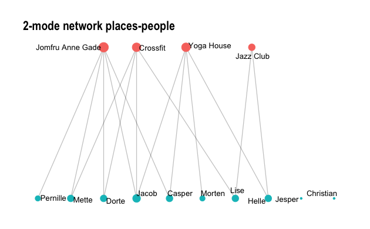

```r
set.seed(1337)
p0 <- g %>% ggraph("bipartite") +
  geom_edge_link(alpha = 0.25) +
  geom_node_point(aes(col = type, size = centrality_degree(mode = 'all'))) +
  geom_node_text(aes(label = name), repel = TRUE) +
  theme_graph() +
  theme(legend.position = 'none') +
  labs(title = '2-mode network places-people')

p0
```

## Creating bipartite projections

### Within the fraph object

- Having a 2-mode network, we can use the `igraph` function `bipartite_projection` to create a 2x 1-mode network out of it.

```r
g_projected <- g %>% bipartite_projection()
```

- We now will have a 1-mode network between people as well as one between places.

```r
g_projected
```

```
$proj1
IGRAPH bbfb07a UNW- 4 5 -- Full bipartite graph
+ attr: name (g/c), name (v/c), weight (e/n)
+ edges from bbfb07a (vertex names):
[1] Yoga House--Jomfru Anne Gade Yoga House--Crossfit         Yoga House--Jazz Club        Crossfit  --Jazz Club        Crossfit  --Jomfru Anne Gade

$proj2
IGRAPH ff97f74 UNW- 10 19 -- Full bipartite graph
+ attr: name (g/c), name (v/c), weight (e/n)
+ edges from ff97f74 (vertex names):
 [1] Pernille--Mette  Pernille--Casper Pernille--Dorte  Pernille--Jacob  Morten  --Casper Morten  --Jacob  Morten  --Helle  Lise    --Mette  Lise    --Dorte  Lise    --Jacob
[11] Lise    --Helle  Mette   --Dorte  Mette   --Jacob  Mette   --Casper Casper  --Jacob  Casper  --Helle  Casper  --Dorte  Dorte   --Jacob  Jacob   --Helle
```

```r
g_places <- g_projected[['proj1']] %>% as_tbl_graph(directed = FALSE)
g_people <- g_projected[['proj2']] %>% as_tbl_graph(directed = FALSE)
```

- Lets take a look:

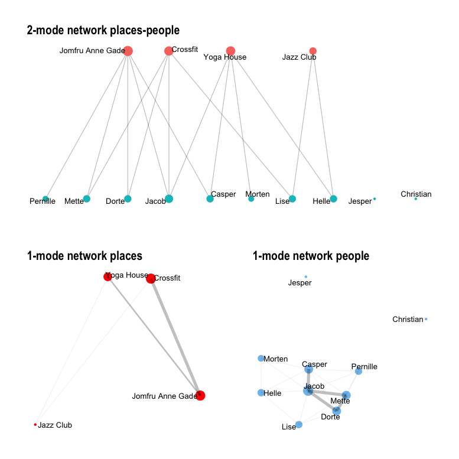

```r
set.seed(1337)
library(patchwork)

p1 <- g_places %>% ggraph(layout = "nicely") +
  geom_node_point(aes(size = centrality_degree(weights = weight)), col = 'red') +
  geom_edge_link(aes(width = weight), alpha = 0.25) +
  scale_edge_width(range = c(0.1, 2)) +
  geom_node_text(aes(label = name), repel = TRUE) +
  theme_graph() +
  theme(legend.position = 'none') +
  labs(title = '1-mode network places')

p2 <- g_people %>% ggraph(layout = "nicely") +
  geom_node_point(aes(size = centrality_degree(weights = weight)), col = 'skyblue2') +
  geom_edge_link(aes(width = weight), alpha = 0.25) +
  scale_edge_width(range = c(0.1, 2)) +
  geom_node_text(aes(label = name), repel = TRUE) +
  theme_graph() +
  theme(legend.position = 'none') +
  labs(title = '1-mode network people')

p0 / (p1 + p2)
```

- Alright, but lets assume we have a 2-mode edgelist to start with… what possibilities do we have then?

```r
el_2m <- g %E>%
  mutate(from_name = .N()$name[from],
         to_name = .N()$name[to]) %>%
  as.tibble() %>%
  select(to_name, from_name) %>%
  rename(from = to_name, to = from_name)
```

```r
el_2m
```

| from | to |
| --- | --- |
| Morten | Yoga House |
| Casper | Yoga House |
| Jacob | Yoga House |
| Helle | Yoga House |
| Lise | Crossfit |
| Mette | Crossfit |
| Dorte | Crossfit |
| Jacob | Crossfit |
| Lise | Jazz Club |
| Helle | Jazz Club |

[output cut: 5 more lines]

- Such an edgelist could obviously be loaded into a graph object the usual way.
- We just have to assign types then

```r
g_2m <- el_2m %>% as_tbl_graph(directed = TRUE)  %N>%
  mutate(type = name %in% (el_2m %>% pull(from)))
```

### Via matrix nultiplication

- We can also do the projection outside of the graph and first create a 2-mode matrix.
- This can easily be done by crosstabulating the edgelist.

```r
mat_2m <- el_2m %>%
  table() %>%
  as.matrix()
```

```r
mat_2m
```

```
          to
from       Crossfit Jazz Club Jomfru Anne Gade Yoga House
  Casper          0         0                1          1
  Dorte           1         0                1          0
  Helle           0         1                0          1
  Jacob           1         0                1          1
  Lise            1         1                0          0
  Mette           1         0                1          0
  Morten          0         0                0          1
  Pernille        0         0                1          0
```

- Again, sparse matrices are usually more efficient.

```r
library(Matrix)
mat_2m %<>% Matrix(sparse = TRUE)

mat_2m
```

```
8 x 4 sparse Matrix of class "dgCMatrix"
          to
from       Crossfit Jazz Club Jomfru Anne Gade Yoga House
  Casper          .         .                1          1
  Dorte           1         .                1          .
  Helle           .         1                .          1
  Jacob           1         .                1          1
  Lise            1         1                .          .
  Mette           1         .                1          .
  Morten          .         .                .          1
  Pernille        .         .                1          .
```

- Matrix algebra can help to do the 1-mode projection directly in the matrix
- Taking the dotproduct of the matrix and its transposed form will result in the 1-mode projection of mode 1 (`m %*% t(m)`)

```r
mat_people <- mat_2m %*% t(mat_2m)
```

```r
mat_people
```

```
8 x 8 sparse Matrix of class "dgCMatrix"
         Casper Dorte Helle Jacob Lise Mette Morten Pernille
Casper        2     1     1     2    .     1      1        1
Dorte         1     2     .     2    1     2      .        1
Helle         1     .     2     1    1     .      1        .
Jacob         2     2     1     3    1     2      1        1
Lise          .     1     1     1    2     1      .        .
Mette         1     2     .     2    1     2      .        1
Morten        1     .     1     1    .     .      1        .
Pernille      1     1     .     1    .     1      .        1
```

```r
mat_places <- t(mat_2m) %*% mat_2m
```

```r
mat_places
```

```
4 x 4 sparse Matrix of class "dgCMatrix"
                 Crossfit Jazz Club Jomfru Anne Gade Yoga House
Crossfit                4         1                3          1
Jazz Club               1         2                .          1
Jomfru Anne Gade        3         .                5          2
Yoga House              1         1                2          4
```

- Note this is still very inefficient, since the matrix is first created in full, and then transformed to a sparse one.
- Directly starting with a sparse matrix makes the process much more efficient
- That makes a huge difference for large graphs
- I here provide you an efficient function to use

```r
## Helper function
el_to_sparse_matrix <- function(data, # the edgelist
                                mode_1, # which variable indicates mode 1
                                mode_2, # which variable indicates mode 2
                                projection = 'none' # If a pojection should be done, possible is 'none', 'mode1', 'mode2'
                                ){

  # Define inputs
  i_input <- data %>% pull({{mode_1}})
  j_input <- data %>% pull({{mode_2}})

  require(Matrix)
  mat <- spMatrix(nrow = i_input %>% n_distinct(),
                  ncol = j_input %>% n_distinct(),
                  i = i_input %>% factor() %>% as.numeric(),
                  j = j_input %>% factor() %>% as.numeric(),
                  x = rep(1, i_input %>% length() ) )

  row.names(mat) <- i_input %>% factor() %>% levels()
  colnames(mat) <- j_input %>% factor() %>% levels()

  # Projection if necessary
  if(projection == 'mode1'){mat %<>% tcrossprod()}
  if(projection == 'mode2'){mat %<>% crossprod()}

  return(mat)
}
```

```r
mat_people <- el_2m %>% el_to_sparse_matrix(from, to, projection = 'mode1')
mat_places <- el_2m %>% el_to_sparse_matrix(from, to, projection = 'mode2')
```

```r
mat_people
```

```
8 x 8 sparse Matrix of class "dsCMatrix"
         Casper Dorte Helle Jacob Lise Mette Morten Pernille
Casper        2     1     1     2    .     1      1        1
Dorte         1     2     .     2    1     2      .        1
Helle         1     .     2     1    1     .      1        .
Jacob         2     2     1     3    1     2      1        1
Lise          .     1     1     1    2     1      .        .
Mette         1     2     .     2    1     2      .        1
Morten        1     .     1     1    .     .      1        .
Pernille      1     1     .     1    .     1      .        1
```

```r
mat_places
```

```
4 x 4 sparse Matrix of class "dsCMatrix"
                 Crossfit Jazz Club Jomfru Anne Gade Yoga House
Crossfit                4         1                3          1
Jazz Club               1         2                .          1
Jomfru Anne Gade        3         .                5          2
Yoga House              1         1                2          4
```

### Via Joins

- FInally, the easiest way

```r
el_people <- el_2m %>% left_join(el_2m, by = 'to') %>%
  select(-to) %>%
  rename(from = from.x, to = from.y) %>%
  filter(from != to) %>%
  count(from, to, name = 'weight')
```

```r
el_people
```

| from | to | weight |
| --- | --- | --- |
| Casper | Dorte | 1 |
| Casper | Helle | 1 |
| Casper | Jacob | 2 |
| Casper | Mette | 1 |
| Casper | Morten | 1 |
| Casper | Pernille | 1 |
| Dorte | Casper | 1 |
| Dorte | Jacob | 2 |
| Dorte | Lise | 1 |
| Dorte | Mette | 2 |

[output cut: 28 more lines]

```r
el_places <- el_2m %>% left_join(el_2m, by = 'from') %>%
  select(-from) %>%
  rename(from = to.x, to = to.y) %>%
  filter(from != to) %>%
  count(from, to, name = 'weight')
```

```r
el_places
```

| from | to | weight |
| --- | --- | --- |
| Crossfit | Jazz Club | 1 |
| Crossfit | Jomfru Anne Gade | 3 |
| Crossfit | Yoga House | 1 |
| Jazz Club | Crossfit | 1 |
| Jazz Club | Yoga House | 1 |
| Jomfru Anne Gade | Crossfit | 3 |
| Jomfru Anne Gade | Yoga House | 2 |
| Yoga House | Crossfit | 1 |
| Yoga House | Jazz Club | 1 |
| Yoga House | Jomfru Anne Gade | 2 |

# Case study: Bibliographic networks

## Basics

Lets talk about bibliographic networks. In short, that are networks between documents which cite each others. That can be (commonly) academic publications, but also patents or policy reports. Conceptually, we can see them as 2 mode networks, between articles and their reference. That helps us to apply some interesting metrics, such as:

- direct citations
- Bibliographic coupling
- Co–citations

Interestingly, different projections of this 2-mode network give the whole resulting 1-mode network a different meaning.

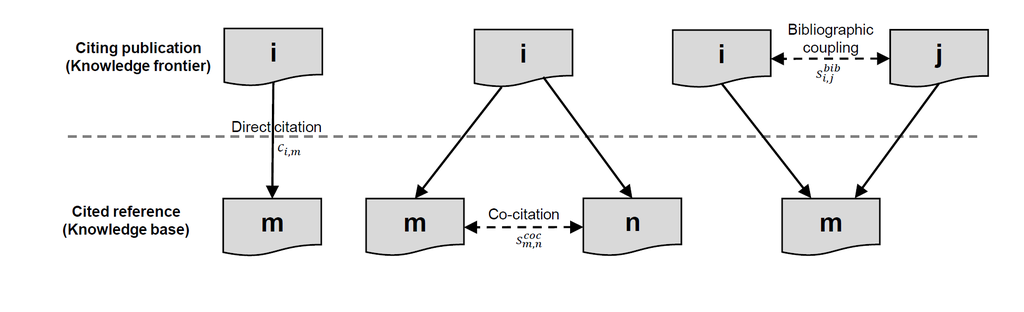

I will illustrate more in detail in the following. The example is based on some own work.[^1]

## The DATA

Lets imagine we do it the hard way. We download some bibliographic data, and have to do all the munging on our own, till we end up with a nice network representation. Lets go through some of these steps together.

`TITLE-ABS-KEY ( "network analysis" ) AND ( LIMIT-TO ( DOCTYPE , "ar" ) OR LIMIT-TO ( DOCTYPE , "cp" ) ) AND ( LIMIT-TO ( LANGUAGE , "English" ) ) AND ( LIMIT-TO ( SRCTYPE , "j" ) OR LIMIT-TO ( SRCTYPE , "p" ) ) AND ( LIMIT-TO ( PUBYEAR , 2021 ) OR LIMIT-TO ( PUBYEAR , 2020 ) OR LIMIT-TO ( PUBYEAR , 2019 ) OR LIMIT-TO ( PUBYEAR , 2018 ) OR LIMIT-TO ( PUBYEAR , 2017 ) OR LIMIT-TO ( PUBYEAR , 2016 ) OR LIMIT-TO ( PUBYEAR , 2015 ) )`

```r
rm(list=ls())
data <- read_csv('https://github.com/SDS-AAU/SDS-master/raw/master/00_data/networks_bibliometrics/biblio_nw.csv')
```

```r
data %>%
  glimpse()
```

```
Rows: 2,000
Columns: 43
$ Authors                     <chr> "Wang D., Cui P., Zhu W.", "Thorsson V., Gibbs D.L., Brown S.D., Wolf D., Bortone D.S., Ou Yang T.-H., Porta-Pardo E., Gao G.F., Plaisier C.L…
$ `Author(s) ID`              <chr> "56780729900;34568700100;7404232311;", "6602742809;57189045500;57199191934;7402650510;11640638800;57194758425;56422456700;57200880842;1360507…
$ Title                       <chr> "Structural deep network embedding", "The Immune Landscape of Cancer", "A Human Interactome in Three Quantitative Dimensions Organized by Sto…
$ Year                        <dbl> 2016, 2018, 2015, 2015, 2015, 2015, 2016, 2015, 2015, 2015, 2015, 2017, 2016, 2015, 2015, 2017, 2017, 2016, 2016, 2016, 2015, 2015, 2016, 201…
$ `Source title`              <chr> "Proceedings of the ACM SIGKDD International Conference on Knowledge Discovery and Data Mining", "Immunity", "Cell", "Proteomics", "IJCAI Int…
$ Volume                      <chr> "13-17-August-2016", "48", "163", "15", "2015-January", "162", "428", "47", "2015", "9", "21", "356", "530", "9", "112", "545", "2", "354", "…
$ Issue                       <chr> NA, "4", "3", "15", NA, "2", "4", "2", NA, "11", "1", "6343", "7590", "JUNE", "51", "7652", NA, "6314", "6295", "4", "3", "6", "6", NA, "7540…
$ `Art. No.`                  <chr> NA, NA, NA, NA, NA, "8281", NA, NA, "bav028", NA, NA, NA, NA, "386", NA, NA, "16270", NA, NA, NA, NA, NA, "7152988", NA, NA, NA, NA, NA, "753…
$ `Page start`                <chr> "1225", "812", "712", "2597", "2111", "375", "688", "106", NA, "2490", "37", "1140", "307", NA, "15672", "48", NA, "847", "163", "694", "176"…
$ `Page end`                  <chr> "1234", "830.e14", "723", "2601", "2117", "390", "692", "114", NA, "2502", "46", "1144", "312", NA, "15677", "53", NA, "850", "166", "707", "…
$ `Page count`                <dbl> NA, NA, NA, NA, NA, NA, NA, NA, NA, NA, NA, NA, NA, 16, NA, NA, NA, NA, NA, NA, NA, NA, NA, NA, NA, NA, NA, NA, NA, NA, NA, NA, NA, NA, NA, N…
$ `Cited by`                  <dbl> 781, 607, 507, 468, 418, 404, 378, 377, 363, 356, 354, 347, 347, 328, 322, 313, 306, 297, 293, 291, 278, 277, 274, 271, 271, 254, 252, 252, 2…
$ DOI                         <chr> "10.1145/2939672.2939753", "10.1016/j.immuni.2018.03.023", "10.1016/j.cell.2015.09.053", "10.1002/pmic.201400515", NA, "10.1016/j.cell.2015.0…
```

[output cut: 30 more lines]

## Preprocessing

```r
data %<>%
  select(EID, Authors, `Author(s) ID`, Title, `Abbreviated Source Title`, Year, Affiliations, `Author Keywords`, `Cited by`, Abstract, References) %>%
  rename(author = Authors,
         author_id = `Author(s) ID`,
         title = Title,
         journal = `Abbreviated Source Title`,
         year = Year,
         affiliation = Affiliations,
         keywords = `Author Keywords`,
         citations = `Cited by`,
         Abstract = Abstract,
         references = References)
```

```r
data[2, 'author']
```

| author |
| --- |
| Thorsson V., Gibbs D.L., Brown S.D., Wolf D., Bortone D.S., Ou Yang T.-H., Porta-Pardo E., Gao G.F., Plaisier C.L., Eddy J.A., Ziv E., Culhane A.C., Paull E.O., Sivakumar I.K.A., Gentles A.J., Malhotr… |

```r
data[2, 'author_id']
```

| author_id |
| --- |
| 6602742809;57189045500;57199191934;7402650510;11640638800;57194758425;56422456700;57200880842;13605075100;35763632700;57201766993;6601969704;57191542706;56497907800;6602276398;57210477632;26658363900;… |

```r
data[2, 'affiliation']
```

| affiliation |
| --- |
| Institute for Systems Biology, 401 Terry Ave N, Seattle, WA 98109, United States; Canada's Michael Smith Genome Sciences Centre, BC Cancer Agency, Vancouver, BC V5Z 4S6, Canada; University of Californ… |

```r
data[2, "keywords"]
```

| keywords |
| --- |
| cancer genomics; immune subtypes; immuno-oncology; immunomodulatory; immunotherapy; integrative network analysis; tumor immunology; tumor microenvironment |

```r
data[2, "references"]
```

| references |
| --- |
| Agarwal, V., Bell, G.W., Nam, J.W., Bartel, D.P., Predicting effective microRNA target sites in mammalian mRNAs (2015) eLife, 4; Alvarez, M.J., Shen, Y., Giorgi, F.M., Lachmann, A., Ding, B.B., Ye, B.… |

```r
data %<>%
  mutate(author = author %>% str_split(', '),
         author_id = author_id %>% str_split(';'),
         affiliation = affiliation %>% str_split(';'),
         keywords = keywords %>% str_split('; '),
         references = references %>% str_split('; '))
```

```r
data %>% select(title, author, citations) %>%
  unnest(author) %>%
  head()
```

| title | author | citations |
| --- | --- | --- |
| Structural deep network embedding | Wang D. | 781 |
| Structural deep network embedding | Cui P. | 781 |
| Structural deep network embedding | Zhu W. | 781 |
| The Immune Landscape of Cancer | Thorsson V. | 607 |
| The Immune Landscape of Cancer | Gibbs D.L. | 607 |
| The Immune Landscape of Cancer | Brown S.D. | 607 |

```r
data %>% select(title, author, citations) %>%
  unnest(author) %>%
  group_by(author) %>%
  summarise(n = n(),
            citations = citations %>% sum(na.rm = TRUE)) %>%
  arrange(desc(citations)) %>%
  head(10)
```

| author | n | citations |
| --- | --- | --- |
| Wang J. | 37 | 3363 |
| Wang Y. | 44 | 2477 |
| Zhang H. | 17 | 2421 |
| Liu Y. | 28 | 2241 |
| Zhang J. | 30 | 2189 |
| Zhang X. | 40 | 2131 |
| Wang Z. | 29 | 2018 |
| Li J. | 23 | 1970 |
| Liu J. | 18 | 1934 |
| Zhang Y. | 36 | 1759 |

## Bipartite Network Generation

I will now transfer them to an article $\rightarrow$ reference edgelist.

```r
el_2m <- data %>% select(EID, references) %>% unnest(references)
```

```r
el_2m %>% head()
```

| EID | references |
| --- | --- |
| 2-s2.0-84985034266 | Belkin, M., Niyogi, P., Laplacian eigenmaps for dimensionality reduction and data representation (2003) Neural Computation, 15 (6), pp. 1373-1396 |
| 2-s2.0-84985034266 | Bengio, Y., Learning deep architectures for ai (2009) Foundations and TrendsR in Machine Learning, 2 (1), pp. 1-127 |
| 2-s2.0-84985034266 | Bengio, Y., Courville, A., Vincent, P., Representation learning: A review and new perspectives (2013) Pattern Analysis and Machine Intelligence, IEEE Transactions on, 35 (8), pp. 1798-1828 |
| 2-s2.0-84985034266 | Cao, S., Lu, W., Xu, Q., Grarep: Learning graph representations with global structural information (2015) Proceedings of the 24th ACM International on Conference on Information and Knowledge Managemen… |
| 2-s2.0-84985034266 | Chang, S., Han, W., Tang, J., Qi, G.-J., Aggarwal, C.C., Huang, T.S., Heterogeneous network embedding via deep architectures (2015) Proceedings of the 21th ACM SIGKDD International Conference on Knowl… |
| 2-s2.0-84985034266 | Dash, N.S., Context and contextual word meaning (2008) SKASE Journal of Theoretical Linguistics, 5 (2), pp. 21-31 |

### Bibliographic Coupling

#### Create the graph

- We now need to create a projection of the 2-mode matrix to one of the modes.
- We could do that more efficiently via using the sparse matrix calculation I did before, but for maximum clarity lets do it via a join.
- We will first create the article to article network.

```r
el_bib <- el_2m %>% left_join(el_2m, by = 'references') %>%
  rename(from = EID.x,
         to = EID.y) %>%
  select(from, to) %>%
  filter(from != to) %>%
  count(from, to, name = 'weight')
```

```r
el_bib %>% head()
```

| from | to | weight |
| --- | --- | --- |
| 2-s2.0-84904891950 | 2-s2.0-84921845246 | 1 |
| 2-s2.0-84904891950 | 2-s2.0-84930958469 | 1 |
| 2-s2.0-84904891950 | 2-s2.0-84931287953 | 1 |
| 2-s2.0-84904891950 | 2-s2.0-84944174312 | 1 |
| 2-s2.0-84904891950 | 2-s2.0-85016005199 | 1 |
| 2-s2.0-84904891950 | 2-s2.0-85030456927 | 1 |

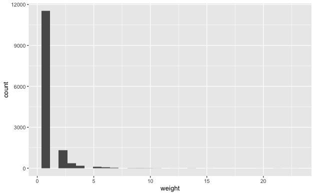

```r
el_bib %>%
  ggplot(aes(x = weight)) +
  geom_histogram()
```

```r
el_bib %<>%
  filter(weight >=2)
```

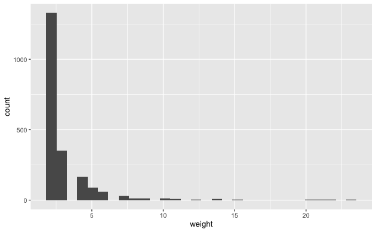

```r
el_bib %>%
  ggplot(aes(x = weight)) +
  geom_histogram()
```

- Ok, great, we now can create a graph

```r
g_bib <- el_bib %>% as_tbl_graph(directed = FALSE) %>%
  igraph::simplify() %>%
  as_tbl_graph(directed = FALSE)
```

```r
g_bib
```

```
# A tbl_graph: 684 nodes and 1046 edges
#
# An undirected simple graph with 109 components
#
# Node Data: 684 x 1 (active)
  name
  <chr>
1 2-s2.0-84909633782
2 2-s2.0-84910060076
3 2-s2.0-84912573275
4 2-s2.0-84918503641
5 2-s2.0-84918774371
6 2-s2.0-84919882800
# … with 678 more rows
#
# Edge Data: 1,046 x 3
   from    to weight
  <int> <int>  <dbl>
1     1    94      4
2     1   162      6
3     1   255     14
# … with 1,043 more rows
```

```r
g_bib <- g_bib %N>%
  filter(!node_is_isolated()) %N>%
  filter(percent_rank(centrality_degree(weights = weight)) >= 0.5)
```

#### Community detection

- A first obvious thing to do would be a community detection

```r
g_bib <- g_bib %N>%
  mutate(com = group_louvain(weights = weight))
```

- Now, we can also create community internal statistics, such as the within-community degree.
- To do so, we use the powerful `morph()` functions of `tidygraph`, which basically let you apply `group_by` style operations on graph structures, where graph calculations are execited on subgraphs.
- That let you e.g. contract nodes, work on the linegraph representation, split communities to separate graphs etc.

```r
g_bib <- g_bib %N>%
  morph(to_split, com) %>%
  mutate(cent_dgr_int = centrality_degree(weights = weight)) %>%
  mutate(com_center = cent_dgr_int == max(cent_dgr_int)) %>%
  unmorph()
```

```r
g_bib %N>%
  as_tibble() %>%
  count(com, sort = TRUE)
```

| com | n |
| --- | --- |
| 1 | 39 |
| 2 | 36 |
| 3 | 33 |
| 4 | 32 |
| 5 | 20 |
| 6 | 19 |
| 7 | 13 |
| 8 | 13 |
| 9 | 12 |
| 10 | 12 |

[output cut: 38 more lines]

```r
g_bib <- g_bib %N>%
  add_count(com, name = 'com_n') %>%
  mutate(com = ifelse(com_n >= 20, com, NA) ) %>%
  select(-com_n)
```

```r
g_bib <- g_bib %N>%
  left_join(data %>% select(EID, title, journal, year, citations), by = c('name' = 'EID')) %>%
  mutate(title = title %>% str_trunc(30))
```

Lets take a look at the network.

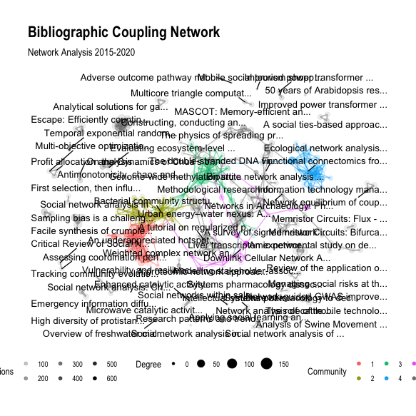

```r
set.seed(1337)
g_bib %>%
  ggraph(layout = 'graphopt') +
  geom_edge_link(aes(width = weight,
                     color = .N()$com[from] %>% as.factor()), # Notice that
                alpha = 0.5,
                show.legend = FALSE) +
      scale_edge_width(range = c(0.5, 2)) +
  geom_node_point(aes(color = com %>% as.factor(),
                      size = centrality_degree(weight = weight),
                      alpha = citations)) +
  geom_node_text(aes(label = title, filter = com_center == TRUE), repel = TRUE) +
  theme_graph()   +
  theme(legend.position = 'bottom') +
  labs(title = 'Bibliographic Coupling Network',
       subtitle = 'Network Analysis 2015-2020',
       color = 'Community',
       size = 'Degree',
       alpha = 'Citations')
```

```r
data %>%
  select(EID, author, year, title, journal, citations) %>%
  inner_join(g_bib %N>% as_tibble() %>% select(name, com, cent_dgr_int), by = c('EID' = 'name')) %>%
  group_by(com) %>%
    arrange(desc(cent_dgr_int)) %>%
    slice(1:10) %>%
  ungroup() %>%
  select(com, title, cent_dgr_int, citations) %>%
  mutate(title = title %>% str_trunc(75))
```

| com | title | cent_dgr_int | citations |
| --- | --- | --- | --- |
| 1 | An underappreciated hotspot of antibiotic resistance: The groundwater ne... | 152 | 46 |
| 1 | Long-term organic fertilization increased antibiotic resistome in phyllo... | 110 | 29 |
| 1 | Influence of zeolite and superphosphate as additives on antibiotic resis... | 88 | 39 |
| 1 | Transfer of antibiotic resistance from manure-amended soils to vegetable... | 86 | 30 |
| 1 | Antibiotic resistome in landfill leachate from different cities of China... | 78 | 38 |
| 1 | Aerobic composting reduces antibiotic resistance genes in cattle manure ... | 76 | 60 |
| 1 | Diversity, abundance, and persistence of antibiotic resistance genes in ... | 66 | 86 |
| 1 | Contributions of the microbial community and environmental variables to ... | 66 | 30 |
| 1 | Impacts of addition of natural zeolite or a nitrification inhibitor on a... | 64 | 133 |
| 1 | Deciphering of microbial community and antibiotic resistance genes in ac... | 64 | 30 |

[output cut: 50 more lines]

## Co-Citation Analysis

- We can now do exactly the same for the reference (=co-citation) network

#### Create the graph

```r
el_cit <- el_2m %>% left_join(el_2m, by = 'EID') %>%
  rename(from = references.x,
         to = references.y) %>%
  select(from, to) %>%
  filter(from != to) %>%
  count(from, to, name = 'weight')
```

```r
el_cit %<>%
  filter(weight >=3,
         !str_detect(from, '\\:\\, '),
         !str_detect(to, '\\:\\, '),
         str_length(from) > 50,
         str_length(to) > 50
         )
```

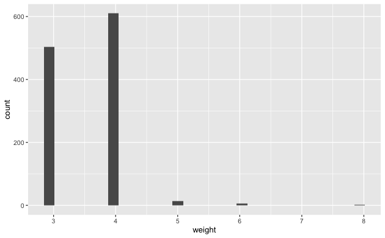

```r
el_cit %>%
  ggplot(aes(x = weight)) +
  geom_histogram()
```

```r
g_cit <- el_cit %>% as_tbl_graph(directed = FALSE) %>%
  igraph::simplify() %>%
  as_tbl_graph(directed = FALSE)  %N>%
  filter(!node_is_isolated()) %N>%
  filter(percent_rank(centrality_degree(weights = weight)) >= 0.5) %N>%
  mutate(com = group_louvain(weights = weight)) %N>%
  morph(to_split, com) %>%
    mutate(cent_dgr_int = centrality_degree(weights = weight)) %>%
    mutate(com_center = cent_dgr_int == max(cent_dgr_int)) %>%
  unmorph()
```

```r
g_cit %N>%
  as_tibble() %>%
  count(com, sort = TRUE)
```

| com | n |
| --- | --- |
| 1 | 19 |
| 2 | 18 |
| 3 | 12 |
| 4 | 7 |
| 5 | 7 |
| 6 | 5 |
| 7 | 5 |
| 8 | 5 |
| 9 | 5 |
| 10 | 5 |

[output cut: 22 more lines]

```r
g_cit <- g_cit %N>%
  add_count(com, name = 'com_n') %>%
  mutate(com = ifelse(com_n >= 10, com, NA) ) %>%
  select(-com_n)
```

Lets take a look at the network.

[figure not shown]

```r
set.seed(1337)
g_cit %>%
  ggraph(layout = 'graphopt') +
  geom_edge_link(aes(width = weight,
                     color = .N()$com[from] %>% as.factor()), # Notice that
                alpha = 0.5,
                show.legend = FALSE) +
      scale_edge_width(range = c(0.5, 2)) +
  geom_node_point(aes(color = com %>% as.factor(),
                      size = centrality_degree(weight = weight),
                      alpha = cent_dgr_int)) +
#  geom_node_text(aes(label = name, filter = com_center == TRUE), repel = TRUE) +
  theme_graph()   +
  theme(legend.position = 'bottom') +
  labs(title = 'Bibliographic Coupling Network',
       subtitle = 'Network Analysis 2015-2020',
       color = 'Community',
       size = 'Degree',
       alpha = 'Citations')
```

```r
g_cit %N>%
  as_tibble() %>%
  group_by(com) %>%
    arrange(desc(cent_dgr_int)) %>%
    slice(1:10) %>%
  ungroup() %>%
  mutate(name = name %>% str_trunc(75)) %>%
  select(com, name, cent_dgr_int)
```

| com | name | cent_dgr_int |
| --- | --- | --- |
| 1 | Farine, D.R., Animal social network inference and permutations for ecolo... | 90 |
| 1 | Boogert, N.J., Farine, D.R., Spencer, K.A., Developmental stress predict... | 62 |
| 1 | Cairns, S.J., Schwager, S.J., A comparison of association indexes (1987)... | 62 |
| 1 | Aplin, L.M., Farine, D.R., Morand-Ferron, J., Cockburn, A., Thornton, A.... | 50 |
| 1 | Farine, D.R., Measuring phenotypic assortment in animal social networks:... | 46 |
| 1 | Lusseau, D., Whitehead, H., Gero, S., Incorporating uncertainty into the... | 38 |
| 1 | Aplin, L.M., Farine, D.R., Morand-Ferron, J., Cole, E.F., Cockburn, A., ... | 32 |
| 1 | Bejder, L., Fletcher, D., Brager, S., A method for testing association p... | 24 |
| 1 | Edenbrow, M., Darden, S.K., Ramnarine, I.W., Evans, J.P., James, R., Cro... | 24 |
| 1 | Farine, D.R., Sheldon, B.C., Selection for territory acquisition is modu... | 24 |

[output cut: 30 more lines]

## Joint analysis

```r
el_joint <- el_2m %>%
  inner_join(g_bib %N>% as_tibble() %>% select(name, com) %>% drop_na(), by = c('EID' = 'name')) %>%
  inner_join(g_cit %N>% as_tibble() %>% select(name, com) %>% drop_na(), by = c('references' = 'name')) %>%
  rename(from = com.x, to = com.y) %>%
  count(from, to, name = 'weight')
```

```r
el_joint
```

| from | to | weight |
| --- | --- | --- |
| 1 | 2 | 66 |
| 2 | 2 | 56 |
| 2 | 3 | 1 |
| 3 | 2 | 1 |
| 4 | 3 | 64 |
| 5 | 2 | 2 |

```r
el_joint %<>%
  mutate(from = paste('bib', from, sep = '_'),
         to = paste('cit', to, sep = '_'))
```

```r
g_joint <- el_joint %>% as_tbl_graph(directed = TRUE)
```

```r
g_joint <- g_joint %N>%
  mutate(type = name %>% str_detect('bib'))
```

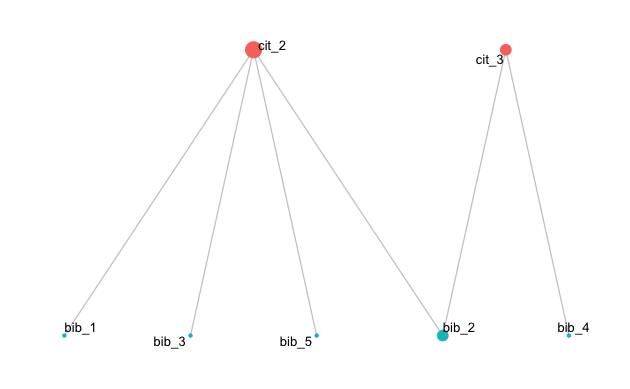

```r
g_joint %>% ggraph("bipartite") +
  geom_edge_link(alpha = 0.25) +
  geom_node_point(aes(col = type, size = centrality_degree(mode = 'all'))) +
  geom_node_text(aes(label = name), repel = TRUE) +
  theme_graph() +
  theme(legend.position = 'none')
```

# Endnotes

### Complementary exercises

Please do **Exercise 1** in the corresponding section on `Github`. This time you are about to do your own bibliographic analysis!

### References

- Rakas, M., & Hain, D. S. (2019). The state of innovation system research: What happens beneath the surface?. Research Policy, 45 (9). DOI: https://doi.org/10.1016/j.respol.2019.04.011

### More info

You can find more info about:

- `tidygraph` [here](https://tidygraph.data-imaginist.com/)
- `ggraph` [here](https://ggraph.data-imaginist.com/)
- `bibliometrix` [here](http://www.bibliometrix.org/)